# Association of nutrition trajectory and outcomes in pediatric leukemia and lymphoma patients

Charles Phillips

Use this template to complete your project throughout the course. Your Final Project presentation in class will be based on the contents of this document. Replace the title/name and text below with your own, but leave the headers.

### Overview

Overview Instructions: In this section, give a brief a description of your project and its goal, what data you are using to complete it, and what three faculty/staff in different fields you have spoken to about your project with a brief summary of what you learned from each person. Include a link to your final project GitHub repository.

The goal of this study is to utilize PEDSnet***, a pediatric learning health system, to describe the body mass index (BMI) patterns during treatment for pediatric leukemia and lymphoma. Trajectory modeling will identify the patients at greatest risk for malnutrition, and compare mortality between subgroups of patients as defined by their BMI trajectory PEDSnet contains electronic health record data from eight pediatric hospitals working together to form a pediatric learning health system. My central hypothesis is that multiple BMI patterns exist within pediatric oncology and early onset undernutrition is associated with increased mortality.

Acknowledgements: I would like to thank the following faculty members for their mentorship for this project. Specifically, I would like to thank Dr. Chen Kenyon for his assistance with trajectory modeling, Dr. Charlie Bailey for his expertise in pediatric oncology, and Elizabeth Smith for her expertise in nutrition for pediatric oncology patients.

Link to final project GitHub repository: https://github.com/phillic2/BMIN503_Final_Project

***Please note PEDSnet is not a publically available dataset. The text in this file is correct and based upon actual data. All files, graphs, tables, and figures are fabricated and modeled after PEDSnet but do NOT contain actual patient data. Therefore, the text will NOT match the figures and graphs. These files should be used for proof of concept only.

### Introduction

Introduction Instructions: In the first paragraph, describe the problem addressed, its significance, and some background to motivate the problem. In the second paragraph, explain why your problem is interdisciplinary, what fields can contribute to its understanding, and incorporate background related to what you learned from meeting with faculty/staff.

According to the National Cancer Institute’s Surveillance, Epidemiology, and End Results (SEER) Program, there are approximately 15,000 cases on childhood cancer annually and the rates are slowly increasing over time. SEER data was recently released for 2014 and the age-adjusted cancer rates for children under the age of 20 was at 18.4 cases per 100,000 people which was a record high in the United States. The Children’s Oncology Group (COG) recognizes nutrition as a critical component of cancer care. Nutritional derangements, including being both underweight and overweight, are known to reduce survival and increase morbidity in pediatric malignancies. Additionally, nutritional derangements are extremely common, with up to three-fourths of children having some nutritional derangement at the time of diagnosis. Variation occurs between institutions regarding nutritional supports and this is further complicated by different indicators used to follow nutritional derangements between centers. Proactive, early nutritional support is known to improve weight and nutritional status but its effect on cancer-related outcomes is unknown. While there is consensus nutritional support is important, the timing and content of these interventions is not standard. One landmark study has examined weight, height, and growth trajectories by broad cancer categories; however the study was limited in that no single group had more than 53 patients. Additionally, because the treatment intensity could have varied significantly within each of the assigned groups of “solid,” “hematological,” and “brain” tumors, it remains unclear if subpopulations within these groups behave very differently compared to the groups as a whole. This project will be the first to use trajectory modeling to determine what nutritional subpopulations exist for pediatric leukemia and lymphoma. Once identified, malnourished patients can be targeted for intervention and assessed for improved outcomes.

This project requires an interdisciplinary at both the clinical and methodologic level. Clinically, it merges developmental pediatrics, nutrition, and oncology. Methodologically, it applies group-based trajectory modeling with traditional epidemiologic research. I have benefited from methodologic discussions with statisticians and researchers who have previously incorporated trajectory modeling including Dr. Chen Kenyon. Clinically, this project has benefited from insite from a pediatric oncologist, Dr. Charles Bailey and a registered dietician, Elizabeth Smith. Leukemia and lymphoma were selected for study due to their relatively common occurrence and relatively similar nutritional concerns during therapy. Based upon prior studies, mortality was selected as the primary outcome of interest.

### Methods

Methods Instructions: In the first paragraph, describe the data used and general methodological approach. Subsequently, incorporate full R code necessary to retrieve and clean data, and perform analysis. Be sure to include a description of code so that others (including your future self) can understand what you are doing and why.

For this retrospective study, a randomly selected subset of leukemia and lymphoma patients diagnosed between 2011-2015 at a PEDSnet hospital were included for study. A pediatric oncology patient was defined as being ≤21 years of age with a new cancer diagnosis for leukemia or lymphoma, and having received treatment at a PEDSnet hospital. Patients who did not receive chemotherapy and were treated with only surgery or radiation were excluded, as their treatment intensity cannot be well measured in PEDSnet data. Patient characteristics including gender, race, diagnosis, age at diagnosis, and mortality data were obtained. A separate dataset contained age-adjusted BMI information and was also exported. BMI information was converted to age-adjusted Z-scores prior to exporting from PEDSnet (code not shown for privacy).

```r
# Load packages
library(readr)
library(dplyr)
library(tidyr)
library(tidyverse)
library(reshape2)
library(traj)
library(ggplot2)

# Load csv files with demographic, diagnosis, and death data
demo_dx_death_fake <- read_csv("~/Documents/MSHP Class/EPI 600 data science/final project/demo_dx_death_fake.csv")

# Load csv file with Body Mass Index (BMI) data
bmi_data_fake <- read_csv("~/Documents/MSHP Class/EPI 600 data science/final project/bmi_data_fake.csv")
```

BMI trajectories were followed for a 1-year period. The starting time point was defined as the day the leukemia or pymphoma was diagnosed. Z-scores were tracked in units of days since diagnosis. For each person, the BMI z-scores were averaged over each month. For the purposes of this study, months 1-11 contained 30 days and month 12 had 35 days. Only complete cases with 12 z-score values were included in the final analysis.

```r
#BMI data cleaning
#delete duplicates
no_dup <- distinct(bmi_data_fake, id, days, .keep_all = TRUE)

#limit to first year after diagnosis
bmi365 <- filter(no_dup, days < 366)

#remove id's with fewer than 20 measurements; these were unlikely to have received full cancer treatment at CHOP
bmi20 <- bmi365 %>%
        group_by(id) %>%
                filter(n() > 19)

#convert days from diagnosis to months
bmi_month <- mutate(bmi20, month = cut(days, breaks=c(0, 30, 60, 90, 120, 150, 180, 210, 240, 270, 300, 330, 366), labels=c(1, 2, 3, 4, 5, 6, 7, 8, 9, 10, 11, 12)))

bmi_month %>% group_by(id, month) %>%
        arrange(desc(month))
```

```
## # A tibble: 17,682 x 5
## # Groups:   id, month [3,490]
##       id measurement  days   zscore  month
##    <int>       <int> <int>    <dbl> <fctr>
##  1     1           2   334  0.58372     12
##  2     1           2   362  0.43649     12
##  3     2           2   332  0.64721     12
##  4     2           2   339  0.64491     12
##  5     2           2   341  0.64414     12
##  6     2           2   346  0.54601     12
##  7     2           2   353  0.51229     12
##  8     2           2   356  0.51108     12
##  9     2           2   360  0.40456     12
## 10     3           2   342 -1.37361     12
## # ... with 17,672 more rows
```

```r
meanz <- bmi_month %>%
  group_by(id, month) %>%
  summarise_each(funs(mean(., na.rm=TRUE)), zscore)

total_month_count <-
        meanz %>% group_by(id) %>%
        summarise(total_months = n_distinct(month)) %>%
        filter(total_months == 12)
                #236 people

final_table <-
        inner_join(total_month_count, meanz, by = 'id')
```

```r
#Transforming the data from long to wide

#Time
#add time column to help with transform
final_table_time <- mutate(final_table, time = month)

#first simplify to just have id's, time, and month
id_month <- select(final_table_time, id,month,time)

#rename to match traj package
id_month_rename <- mutate(id_month, time = factor(time, levels=c(1, 2, 3, 4, 5, 6, 7, 8, 9, 10, 11, 12), labels=c("time.1", "time.2","time.3","time.4","time.5","time.6","time.7","time.8","time.9","time.10","time.11","time.12")))

#long to wide for time
time_df <- dcast(id_month_rename, id ~ time, value.var="month")
time_df_asnum <- time_df %>% mutate_if(is.character, as.numeric)
time_df_asnum <- time_df_asnum %>% mutate_if(is.integer, as.numeric)

#Data
#add time column to help with transform
final_table_data <- mutate(final_table, data = month)

#first simplify to just have id's, time, and month
id_data <- select(final_table_data, id,zscore,data)

#rename to match traj package
id_data_rename <- mutate(id_data, data = factor(data, levels=c(1, 2, 3, 4, 5, 6, 7, 8, 9, 10, 11, 12), labels=c("data.1", "data.2","data.3","data.4","data.5","data.6","data.7","data.8","data.9","data.10","data.11","data.12")))

#long to wide for time
data_df <- dcast(id_data_rename, id ~ data, value.var="zscore")
data_df_asnum <- data_df %>% mutate_if(is.integer, as.numeric)
```

Z-score trends were described using group-based trajectory modeling (GBTM). GBTM uses trajectory subgroups to identify and characterize differential patterns of individual change over time. The traj package used “implements the three-step procedure proposed by Leffondree et al. (2004) to identify clusters of individual longitudinal trajectories. The procedure involves (1) calculating 24 measures describing the features of the trajectories (see Appendix 1 for measures); (2) using factor analysis to select a subset of the 24 measures and (3) using cluster analysis to identify clusters of trajectories, and classify each individual trajectory in one of the clusters.”

Cubic clustering criterion and scree plots were obtained to determine the optimal number of clusters. Two clusters were performed to compare the predicted optimal number of clusters to an internal control. Four and eight group solutions were performed.

Based upon the trajectories, the group with the lowest mean BMI z-score was compared to the other groups. Chi square test and logistic regression modeling were used to describe the association between the malnutrition subfroup and the outcome of interest, mortality. Univariate and multivariate regression was performed to control for covariates. Nutrition subgroup was the primary predictor variable of interest.

### Results

Results Instructions: Describe your results and include relevant tables, plots, and code/comments used to obtain them. End with a brief conclusion of your findings related to the question you set out to address. You can include references if you’d like, but this is not required.

The descriptive statistics for the cohort characteristics including demographics, diagnosis information, and mortality data are shown.

```r
# Demographic, diagnosis, and death descriptive statistics
# 351 patients total

# Convert age at diagnosis from months to years
demo_dx_death <- mutate(demo_dx_death_fake, age_at_diagnosis_years = age_at_diagnosis/12)

# Convert character variables to factors
demo_dx_death <- demo_dx_death %>% mutate_if(is.character, as.factor)

# Summarize table
summary(demo_dx_death)
```

```
##        id           gender         race                      diagnosis   age_at_diagnosis deceased  age_at_diagnosis_years
##  Min.   :  1.0   female:196   asian  : 58   ALL                   : 99   Min.   :  4.00   no :324   Min.   : 0.3333
##  1st Qu.: 88.5   male  :155   black  :212   AML                   :220   1st Qu.: 50.35   yes: 27   1st Qu.: 4.1958
##  Median :176.0                unknown: 19   Hogkin's lymphoma     : 15   Median : 89.00             Median : 7.4167
##  Mean   :176.0                white  : 62   Non-Hodgkin's lymphoma: 17   Mean   :108.26             Mean   : 9.0221
##  3rd Qu.:263.5                                                           3rd Qu.:167.25             3rd Qu.:13.9375
##  Max.   :351.0                                                           Max.   :291.70             Max.   :24.3083
```

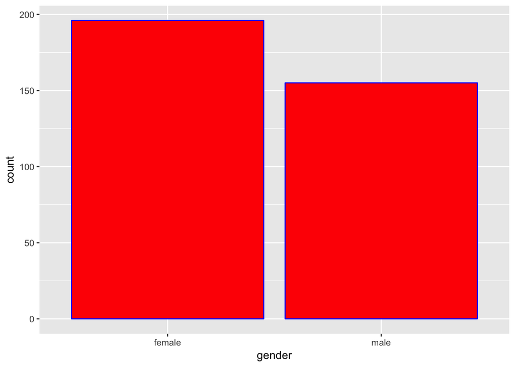

```r
ggplot(data=demo_dx_death, aes(x=gender)) +
    geom_bar(color = 'blue', fill = 'red')
```

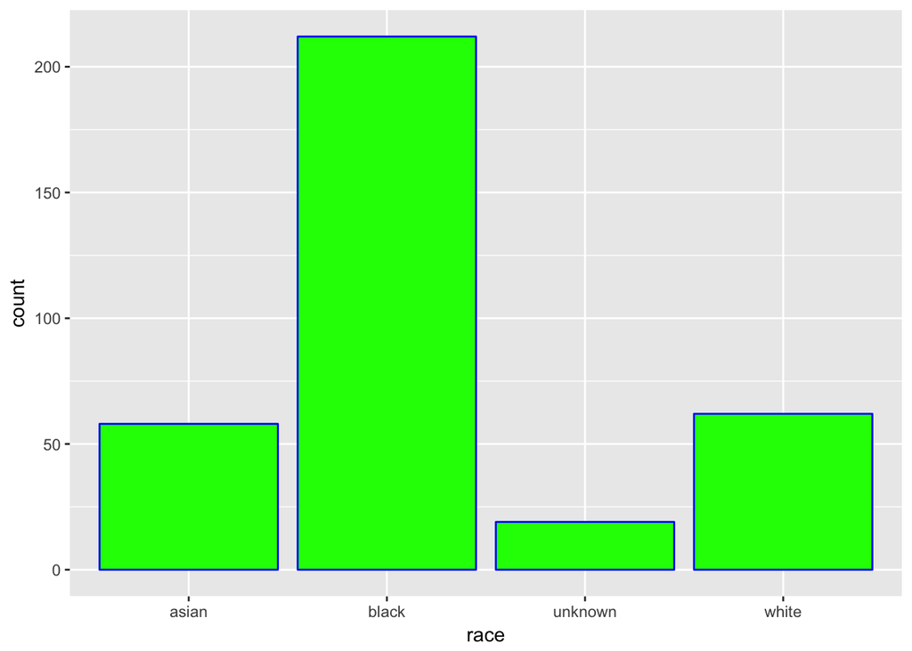

```r
ggplot(data=demo_dx_death, aes(x=race)) +
    geom_bar(color = 'blue', fill = 'green')
```

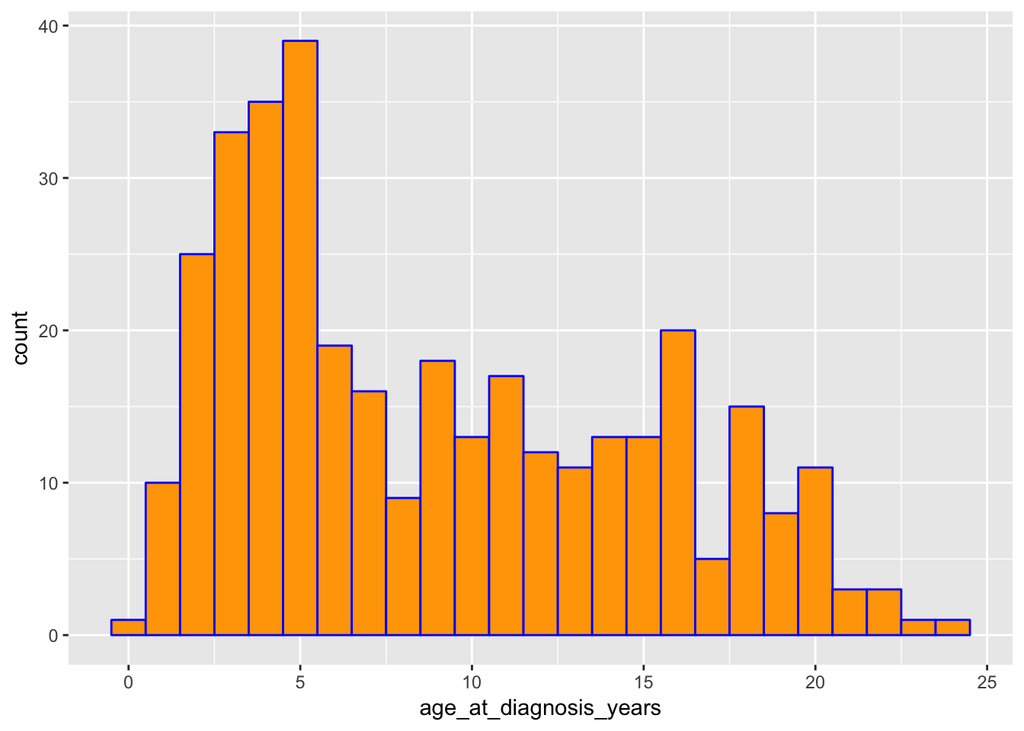

```r
ggplot(data=demo_dx_death, aes(x=age_at_diagnosis_years)) +
    geom_histogram(binwidth = 1, color = 'blue', fill = 'orange')
```

```r
common_diagnosis <- count(demo_dx_death, diagnosis)

common_diagnosis_pct <- mutate(common_diagnosis, n/351)
View(common_diagnosis_pct)
```

```r
#Statistics for cohort of complete cases with 12 z-scores
nrow(total_month_count)
```

```
## [1] 236
```

```r
# 236 complete cases

# Repeat demographic analysis for cohort of complete cases, 236 persons. (full cohort 351 persons)
death_cluster2 <- inner_join(demo_dx_death, id_month, by='id')

# Summarize table
summary(death_cluster2)
```

```
##        id            gender          race                       diagnosis    age_at_diagnosis deceased   age_at_diagnosis_years     month           time
##  Min.   :  3.00   female:1632   asian  : 408   ALL                   : 612   Min.   : 17.80   no :2628   Min.   : 1.483         1      : 236   1      : 236
##  1st Qu.: 85.75   male  :1200   black  :1728   AML                   :2004   1st Qu.: 50.80   yes: 204   1st Qu.: 4.233         2      : 236   2      : 236
##  Median :172.50                 unknown: 180   Hogkin's lymphoma     :  60   Median : 77.90              Median : 6.492         3      : 236   3      : 236
##  Mean   :173.16                 white  : 516   Non-Hodgkin's lymphoma: 156   Mean   : 99.85              Mean   : 8.321         4      : 236   4      : 236
##  3rd Qu.:256.25                                                              3rd Qu.:145.85              3rd Qu.:12.154         5      : 236   5      : 236
##  Max.   :351.00                                                              Max.   :240.50              Max.   :20.042         6      : 236   6      : 236
##                                                                                                                                 (Other):1416   (Other):1416
```

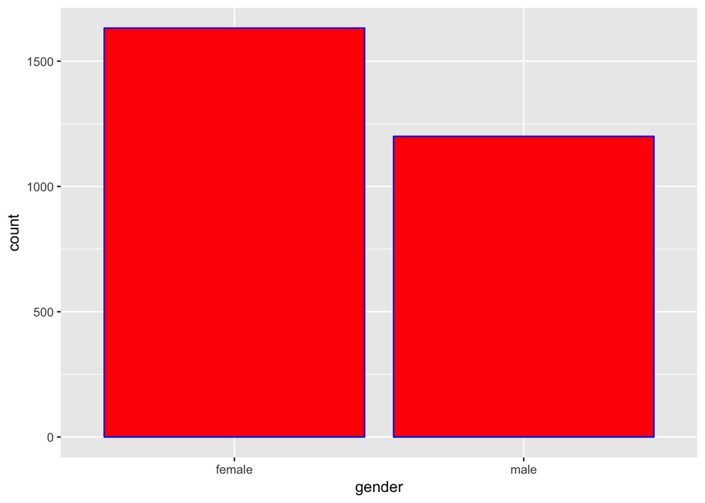

```r
ggplot(data=death_cluster2, aes(x=gender)) +
    geom_bar(color = 'blue', fill = 'red')
```

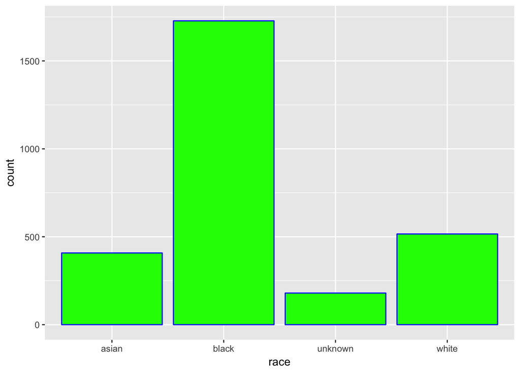

```r
ggplot(data=death_cluster2, aes(x=race)) +
    geom_bar(color = 'blue', fill = 'green')
```

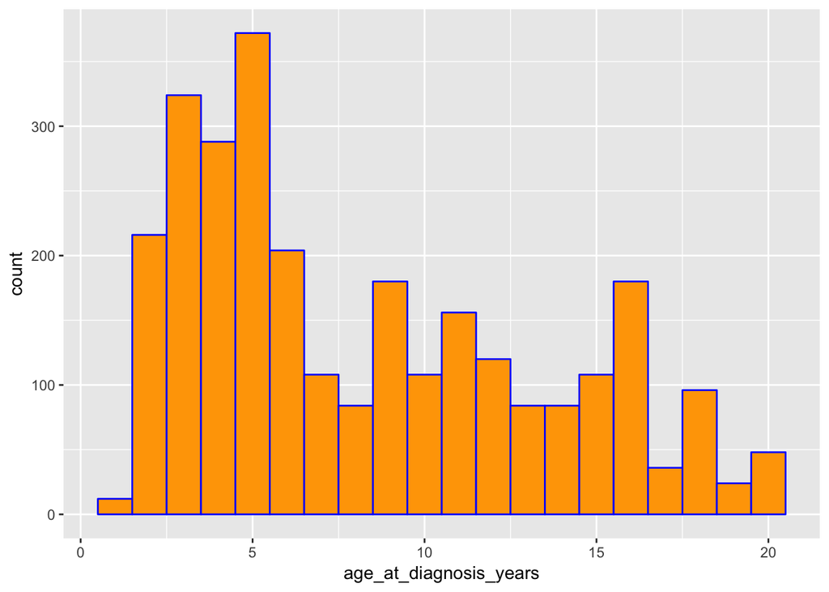

```r
ggplot(data=death_cluster2, aes(x=age_at_diagnosis_years)) +
    geom_histogram(binwidth = 1, color = 'blue', fill = 'orange')
```

```r
common_diagnosis2 <- count(death_cluster2, diagnosis)

common_diagnosis_pct2 <- mutate(common_diagnosis2, n/351)
View(common_diagnosis_pct2)
```

Next the BMI data was analyzed and the results are shown.

```r
#range for Z-scores
min(final_table$zscore)
```

```
## [1] -13.69889
```

```r
max(final_table$zscore)
```

```
## [1] 3.480251
```

```r
mean(final_table$zscore)
```

```
## [1] 0.2603356
```

```r
median(final_table$zscore)
```

```
## [1] 0.3106994
```

```r
sd(final_table$zscore)
```

```
## [1] 1.199072
```